# **Capstone project: Providing data-driven suggestions for HR**

## Description and deliverables

This capstone project is an opportunity for you to analyze a dataset and build predictive models that can provide insights to the Human Resources (HR) department of a large consulting firm.

Upon completion, you will have two artifacts that you will be able to present to future employers. One is a brief one-page summary of this project that you will present to external stakeholders as the data professional in Salifort Motors. The other is a complete code notebook provided here. Based on your prior coursework, select one method to complete this project: use either a regression model or a machine learning model to predict whether an employee will leave the company. The exemplar following this actiivty shows both approaches, but you only need to do one.

In your deliverables, you will include the model evaluation (and interpretation if applicable), a data visualization(s) of your choice that is directly related to the question you ask, ethical considerations, and the resources you used to troubleshoot and find answers or solutions.

# **PACE stages**

## **Pace: Plan**

Consider the questions in your PACE Strategy Document to reflect on the Plan stage.

In this stage, consider the following:

### Understand the business scenario and problem

The HR department at Salifort Motors wants to take some initiatives to improve employee satisfaction levels at the company. They collected data from employees, but now they don’t know what to do with it. They refer to you as a data analytics professional and ask you to provide data-driven suggestions based on your understanding of the data. They have the following question: what’s likely to make the employee leave the company?

Your goals in this project are to analyze the data collected by the HR department and to build a model that predicts whether or not an employee will leave the company.

If you can predict employees likely to quit, it might be possible to identify factors that contribute to their leaving. Because it is time-consuming and expensive to find, interview, and hire new employees, increasing employee retention will be beneficial to the company.

### Familiarize yourself with the HR dataset

The dataset that you'll be using in this lab contains 15,000 rows and 10 columns for the variables listed below.

**Note:** you don't need to download any data to complete this lab. For more information about the data, refer to its source on [Kaggle](https://www.kaggle.com/datasets/mfaisalqureshi/hr-analytics-and-job-prediction?select=HR_comma_sep.csv).

| Variable | Description |  |
| --- | --- | --- |
| satisfaction_level | Employee-reported job satisfaction level [0–1] |  |
| last_evaluation | Score of employee's last performance review [0–1] |  |
| number_project | Number of projects employee contributes to |  |
| average_monthly_hours | Average number of hours employee worked per month |  |
| time_spend_company | How long the employee has been with the company (years) |  |
| Work_accident | Whether or not the employee experienced an accident while at work |  |
| left | Whether or not the employee left the company |  |
| promotion_last_5years | Whether or not the employee was promoted in the last 5 years |  |
| Department | The employee's department |  |
| salary | The employee's salary (U.S. dollars) |  |

💭

### Reflect on these questions as you complete the plan stage.

- Who are your stakeholders for this project?
- What are you trying to solve or accomplish?
- What are your initial observations when you explore the data?
- What resources do you find yourself using as you complete this stage?
- Do you have any ethical considerations in this stage?

1) My stakeholders are the HR team and other relevant employees and stakeholders for the Salifort Motors company. 2) I'm trying to make a successful model at predicting whether an employee will leave the company or not. 3) My first observation is that it includes many factors but the data does not completely encompass possible reasons why an employee has left the company. In the future, it may be useful to pursue data from exit surveys to investigate why employees have left the company. 4) I have not used any resources yet, but plan to use my previous python labs from my Waze portfolio project, in which I followed a similar plan to the project proposal I set up for this project. 5) I don't have any ethical concerns at this time because the data is anonymized, so all identifying personal information has been removed. Additionally, this project is aimed at improving employees' experiences and satisfaction levels, not for hiring purposes or for making decisions about employment status.

## Step 1. Imports

- Import packages
- Load dataset

### Import packages

```python
# Import general packages

import pandas as pd
import numpy as np

# Import visualization packages

import seaborn as sns
import matplotlib.pyplot as plt

# Packages for Logistic Regression, Confusion Matrix, and metrics

from sklearn.linear_model import LogisticRegression
from sklearn.model_selection import GridSearchCV, train_test_split
from sklearn.metrics import roc_auc_score, roc_curve, auc
from sklearn.metrics import classification_report, accuracy_score, precision_score, recall_score,\
f1_score, confusion_matrix, ConfusionMatrixDisplay, RocCurveDisplay, PrecisionRecallDisplay

# Import data modeling packages

from sklearn.ensemble import RandomForestClassifier
from xgboost import XGBClassifier
from xgboost import plot_importance

# Import package to save models

import pickle
```

### Load dataset

`Pandas` is used to read a dataset called **`HR_capstone_dataset.csv`.** As shown in this cell, the dataset has been automatically loaded in for you. You do not need to download the .csv file, or provide more code, in order to access the dataset and proceed with this lab. Please continue with this activity by completing the following instructions.

```python
# RUN THIS CELL TO IMPORT YOUR DATA.

# Load dataset into a dataframe
df0 = pd.read_csv("HR_capstone_dataset.csv")


# Display first few rows of the dataframe

df0.head()
```

|  | satisfaction_level | last_evaluation | number_project | average_montly_hours | time_spend_company | Work_accident | left | promotion_last_5years | Department | salary |
| --- | --- | --- | --- | --- | --- | --- | --- | --- | --- | --- |
| 0 | 0.38 | 0.53 | 2 | 157 | 3 | 0 | 1 | 0 | sales | low |
| 1 | 0.80 | 0.86 | 5 | 262 | 6 | 0 | 1 | 0 | sales | medium |
| 2 | 0.11 | 0.88 | 7 | 272 | 4 | 0 | 1 | 0 | sales | medium |
| 3 | 0.72 | 0.87 | 5 | 223 | 5 | 0 | 1 | 0 | sales | low |
| 4 | 0.37 | 0.52 | 2 | 159 | 3 | 0 | 1 | 0 | sales | low |

```python
# Make a copy of the original dataset

df = df0.copy()
```

## Step 2. Data Exploration (Initial EDA and data cleaning)

- Understand your variables
- Clean your dataset (missing data, redundant data, outliers)

### Gather basic information about the data

```python
# Gather basic information about the data

df.info()
```

```
<class 'pandas.core.frame.DataFrame'>
RangeIndex: 14999 entries, 0 to 14998
Data columns (total 10 columns):
 #   Column                 Non-Null Count  Dtype
---  ------                 --------------  -----
 0   satisfaction_level     14999 non-null  float64
 1   last_evaluation        14999 non-null  float64
 2   number_project         14999 non-null  int64
 3   average_montly_hours   14999 non-null  int64
 4   time_spend_company     14999 non-null  int64
 5   Work_accident          14999 non-null  int64
 6   left                   14999 non-null  int64
 7   promotion_last_5years  14999 non-null  int64
 8   Department             14999 non-null  object
 9   salary                 14999 non-null  object
dtypes: float64(2), int64(6), object(2)
memory usage: 1.1+ MB
```

### Gather descriptive statistics about the data

```python
# Gather descriptive statistics about the data
df.describe()
```

|  | satisfaction_level | last_evaluation | number_project | average_montly_hours | time_spend_company | Work_accident | left | promotion_last_5years |
| --- | --- | --- | --- | --- | --- | --- | --- | --- |
| count | 14999.000000 | 14999.000000 | 14999.000000 | 14999.000000 | 14999.000000 | 14999.000000 | 14999.000000 | 14999.000000 |
| mean | 0.612834 | 0.716102 | 3.803054 | 201.050337 | 3.498233 | 0.144610 | 0.238083 | 0.021268 |
| std | 0.248631 | 0.171169 | 1.232592 | 49.943099 | 1.460136 | 0.351719 | 0.425924 | 0.144281 |
| min | 0.090000 | 0.360000 | 2.000000 | 96.000000 | 2.000000 | 0.000000 | 0.000000 | 0.000000 |
| 25% | 0.440000 | 0.560000 | 3.000000 | 156.000000 | 3.000000 | 0.000000 | 0.000000 | 0.000000 |
| 50% | 0.640000 | 0.720000 | 4.000000 | 200.000000 | 3.000000 | 0.000000 | 0.000000 | 0.000000 |
| 75% | 0.820000 | 0.870000 | 5.000000 | 245.000000 | 4.000000 | 0.000000 | 0.000000 | 0.000000 |
| max | 1.000000 | 1.000000 | 7.000000 | 310.000000 | 10.000000 | 1.000000 | 1.000000 | 1.000000 |

### Rename columns

As a data cleaning step, rename the columns as needed. Standardize the column names so that they are all in `snake_case`, correct any column names that are misspelled, and make column names more concise as needed.

```python
# Display all column names
list(df.columns)
```

```
['satisfaction_level',
 'last_evaluation',
 'number_project',
 'average_montly_hours',
 'time_spend_company',
 'Work_accident',
 'left',
 'promotion_last_5years',
 'Department',
 'salary']
```

```python
# Install skimpy to change column names to snakecase
!pip install skimpy
```

```python
# Import libraries to clean column names

from skimpy import clean_columns
```

```python
# Rename columns as needed

# Change column names to snake_case for uniformity
df = clean_columns(df)

# Rename select columns for consistency and to fix spelling mistakes

df = df.rename(columns={'satisfaction_level' : 'satisfaction_score',
                        'last_evaluation' : 'performance_score',
                        'number_project' : 'projects',
                        'average_montly_hours' : 'hours_per_month',
                        'time_spend_company' : 'tenure',
                        'promotion_last_5years' : 'recent_promotion'})

# Display all column names after the update
list(df.columns)
```

```
['satisfaction_score',
 'performance_score',
 'projects',
 'hours_per_month',
 'tenure',
 'work_accident',
 'left',
 'recent_promotion',
 'department',
 'salary']
```

### Check missing values

Check for any missing values in the data.

```python
# Check for missing values
df.isnull().sum()
```

```
satisfaction_score    0
performance_score     0
projects              0
hours_per_month       0
tenure                0
work_accident         0
left                  0
recent_promotion      0
department            0
salary                0
dtype: int64
```

### Check duplicates

Check for any duplicate entries in the data.

```python
# Display count for number of duplicates
df.duplicated().sum()
```

```
3008
```

```python
# Inspect some rows containing duplicates as needed
df[df.duplicated()]
```

|  | satisfaction_score | performance_score | projects | hours_per_month | tenure | work_accident | left | recent_promotion | department | salary |
| --- | --- | --- | --- | --- | --- | --- | --- | --- | --- | --- |
| 396 | 0.46 | 0.57 | 2 | 139 | 3 | 0 | 1 | 0 | sales | low |
| 866 | 0.41 | 0.46 | 2 | 128 | 3 | 0 | 1 | 0 | accounting | low |
| 1317 | 0.37 | 0.51 | 2 | 127 | 3 | 0 | 1 | 0 | sales | medium |
| 1368 | 0.41 | 0.52 | 2 | 132 | 3 | 0 | 1 | 0 | RandD | low |
| 1461 | 0.42 | 0.53 | 2 | 142 | 3 | 0 | 1 | 0 | sales | low |
| ... | ... | ... | ... | ... | ... | ... | ... | ... | ... | ... |
| 14994 | 0.40 | 0.57 | 2 | 151 | 3 | 0 | 1 | 0 | support | low |
| 14995 | 0.37 | 0.48 | 2 | 160 | 3 | 0 | 1 | 0 | support | low |
| 14996 | 0.37 | 0.53 | 2 | 143 | 3 | 0 | 1 | 0 | support | low |
| 14997 | 0.11 | 0.96 | 6 | 280 | 4 | 0 | 1 | 0 | support | low |
| 14998 | 0.37 | 0.52 | 2 | 158 | 3 | 0 | 1 | 0 | support | low |

3008 rows × 10 columns

```python
# Drop duplicates and save resulting dataframe in a new variable as needed

df = df.drop_duplicates(keep='first')

# Display first few rows of new dataframe as needed

df.head()
```

|  | satisfaction_score | performance_score | projects | hours_per_month | tenure | work_accident | left | recent_promotion | department | salary |
| --- | --- | --- | --- | --- | --- | --- | --- | --- | --- | --- |
| 0 | 0.38 | 0.53 | 2 | 157 | 3 | 0 | 1 | 0 | sales | low |
| 1 | 0.80 | 0.86 | 5 | 262 | 6 | 0 | 1 | 0 | sales | medium |
| 2 | 0.11 | 0.88 | 7 | 272 | 4 | 0 | 1 | 0 | sales | medium |
| 3 | 0.72 | 0.87 | 5 | 223 | 5 | 0 | 1 | 0 | sales | low |
| 4 | 0.37 | 0.52 | 2 | 159 | 3 | 0 | 1 | 0 | sales | low |

```python
# Explore engineered features

# Create column for total hours worked over the entire tenure (by multiplying hours/month and tenure in years times months in a year)
df['total_hours'] = df['hours_per_month'] * df['tenure'] * 12

# Describe new column
df['total_hours'].describe()
```

```
count    11991.000000
mean      8174.790093
std       4083.536104
min       2304.000000
25%       5292.000000
50%       6912.000000
75%       9708.000000
max      34080.000000
Name: total_hours, dtype: float64
```

```python
# Create a binary column labeled full time where employees receive a 1 (yes) if they work greater than 130 hours/month
# 30-40 hrs/week is the average workweek, so 120-160 hrs/month is the average hours of work in a month.
# 130 hours/month is a common threshold for part time vs full time.

df['full_time'] = np.where(df['hours_per_month'] > 130, 1, 0)

# Describe new column
df['full_time'].describe()
```

```
count    11991.000000
mean         0.948878
std          0.220255
min          0.000000
25%          1.000000
50%          1.000000
75%          1.000000
max          1.000000
Name: full_time, dtype: float64
```

```python
# Create a binary column labeled hard worker where employees receive a 1 (yes) if they work greater than 240 hours/month
# 240 hours is 1.5 times the threshold for a full-time employee (160 hrs/month)

df['hard_worker'] = np.where(df['hours_per_month'] > 240, 1, 0)

# Describe new column
df['hard_worker'].describe()
```

```
count    11991.000000
mean         0.267117
std          0.442472
min          0.000000
25%          0.000000
50%          0.000000
75%          1.000000
max          1.000000
Name: hard_worker, dtype: float64
```

```python
# Create a binary column labeled high performer where employees receive a 1 (yes) if they earned a performance score of greater than or equal to 0.9 or have had a recent promotion (1)

df['high_performer'] = np.where((df['performance_score'] >= 0.9) | (df['recent_promotion'] == 1), 1, 0)

# Describe new column
df['high_performer'].describe()
```

```
count    11991.000000
mean         0.207739
std          0.405706
min          0.000000
25%          0.000000
50%          0.000000
75%          0.000000
max          1.000000
Name: high_performer, dtype: float64
```

```python
# Create a new column labeled happy worker where employees receive a 1 (yes) if their satisfaction_score is greater or equal to 0.7

df['happy_worker'] = np.where(df['satisfaction_score'] >= 0.7, 1, 0)

# Describe new column
df['happy_worker'].describe()
```

```
count    11991.000000
mean         0.451255
std          0.497639
min          0.000000
25%          0.000000
50%          0.000000
75%          1.000000
max          1.000000
Name: happy_worker, dtype: float64
```

### Check outliers

Check for outliers in the data.

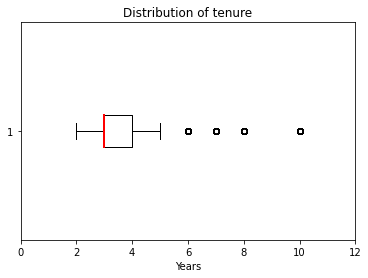

```python
# Create a boxplot to visualize distribution of `time_spend_company` and detect any outliers

plt.boxplot(df['tenure'], vert=False, medianprops=dict(color='red', linewidth=2))
plt.xlim(0, 12)
plt.title('Distribution of tenure')
plt.xlabel('Years')
plt.show();
```

```python
# Determine the number of rows containing outliers

# Calculate the quantile values and the interquantile range

Q1 = df['tenure'].quantile(0.25)
Q3 = df['tenure'].quantile(0.75)

IQR = Q3 - Q1

print(IQR)

# Calculate the upper and lower limits for outliers

lower_limit = Q1 - (1.5 * IQR)
upper_limit = Q3 + (1.5 * IQR)

print(lower_limit, upper_limit)

# Find rows containing outliers and create a mask

outliers_tenure = (df['tenure'] < lower_limit) | (df['tenure'] > upper_limit)

# Calculate the number of rows containing outliers

outliers_tenure.sum()
```

```
1.0
1.5 5.5
```

```
824
```

Certain types of models are more sensitive to outliers than others. When you get to the stage of building your model, consider whether to remove outliers, based on the type of model you decide to use.

```python
# Create a copy of the dataset without outliers to use for models with this requirement
# Reset the index so rows are relabeled in continuous counting order

df_no_outliers = df[~outliers_tenure].reset_index(drop = True)

df_no_outliers.info()
```

```
<class 'pandas.core.frame.DataFrame'>
RangeIndex: 11167 entries, 0 to 11166
Data columns (total 15 columns):
 #   Column              Non-Null Count  Dtype
---  ------              --------------  -----
 0   satisfaction_score  11167 non-null  float64
 1   performance_score   11167 non-null  float64
 2   projects            11167 non-null  int64
 3   hours_per_month     11167 non-null  int64
 4   tenure              11167 non-null  int64
 5   work_accident       11167 non-null  int64
 6   left                11167 non-null  int64
 7   recent_promotion    11167 non-null  int64
 8   department          11167 non-null  object
 9   salary              11167 non-null  object
 10  total_hours         11167 non-null  int64
 11  full_time           11167 non-null  int64
 12  hard_worker         11167 non-null  int64
 13  high_performer      11167 non-null  int64
 14  happy_worker        11167 non-null  int64
dtypes: float64(2), int64(11), object(2)
memory usage: 1.3+ MB
```

```python
# Check for other potential outliers in the dataframe excluding outliers

df_no_outliers.describe()
```

|  | satisfaction_score | performance_score | projects | hours_per_month | tenure | work_accident | left | recent_promotion | total_hours | full_time | hard_worker | high_performer | happy_worker |
| --- | --- | --- | --- | --- | --- | --- | --- | --- | --- | --- | --- | --- | --- |
| count | 11167.000000 | 11167.000000 | 11167.000000 | 11167.000000 | 11167.000000 | 11167.000000 | 11167.000000 | 11167.000000 | 11167.000000 | 11167.000000 | 11167.000000 | 11167.000000 | 11167.000000 |
| mean | 0.631944 | 0.715901 | 3.786066 | 200.144533 | 3.109161 | 0.152413 | 0.168532 | 0.014417 | 7543.592012 | 0.951016 | 0.264619 | 0.204083 | 0.452494 |
| std | 0.239064 | 0.167595 | 1.164198 | 48.563047 | 0.899277 | 0.359437 | 0.374355 | 0.119209 | 3188.683731 | 0.215843 | 0.441150 | 0.403048 | 0.497760 |
| min | 0.090000 | 0.360000 | 2.000000 | 96.000000 | 2.000000 | 0.000000 | 0.000000 | 0.000000 | 2304.000000 | 0.000000 | 0.000000 | 0.000000 | 0.000000 |
| 25% | 0.490000 | 0.570000 | 3.000000 | 157.000000 | 2.000000 | 0.000000 | 0.000000 | 0.000000 | 5184.000000 | 1.000000 | 0.000000 | 0.000000 | 0.000000 |
| 50% | 0.660000 | 0.720000 | 4.000000 | 199.000000 | 3.000000 | 0.000000 | 0.000000 | 0.000000 | 6552.000000 | 1.000000 | 0.000000 | 0.000000 | 0.000000 |
| 75% | 0.820000 | 0.860000 | 5.000000 | 243.000000 | 4.000000 | 0.000000 | 0.000000 | 0.000000 | 9216.000000 | 1.000000 | 1.000000 | 0.000000 | 1.000000 |
| max | 1.000000 | 1.000000 | 7.000000 | 310.000000 | 5.000000 | 1.000000 | 1.000000 | 1.000000 | 18600.000000 | 1.000000 | 1.000000 | 1.000000 | 1.000000 |

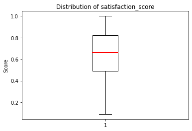

```python
# Create a boxplot to visualize distribution of `satisfaction_score` and detect any outliers

plt.boxplot(df_no_outliers['satisfaction_score'], medianprops=dict(color='red', linewidth=2))
plt.title('Distribution of satisfaction_score')
plt.ylabel('Score')
plt.show();
```

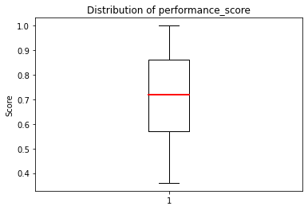

```python
# Create a boxplot to visualize distribution of `performance_score` and detect any outliers

plt.boxplot(df_no_outliers['performance_score'], medianprops=dict(color='red', linewidth=2))
plt.title('Distribution of performance_score')
plt.ylabel('Score')
plt.show();
```

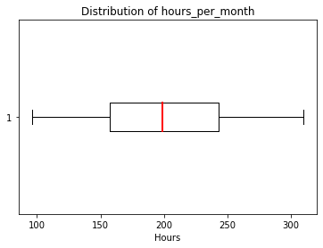

```python
# Create a boxplot to visualize distribution of `hours_per_month` and detect any outliers

plt.boxplot(df_no_outliers['hours_per_month'], vert=False, medianprops=dict(color='red', linewidth=2))
plt.title('Distribution of hours_per_month')
plt.xlabel('Hours')
plt.show();
```

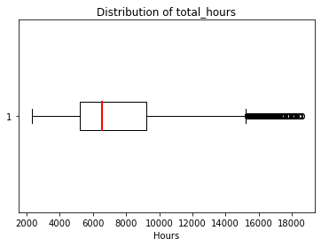

```python
# Create a boxplot to visualize distribution of `total_hours` and detect any outliers

plt.boxplot(df_no_outliers['total_hours'], vert=False, medianprops=dict(color='red', linewidth=2))
plt.title('Distribution of total_hours')
plt.xlabel('Hours')
plt.show();
```

```python
# Determine the number of rows containing outliers for total_hours

# Calculate the quantile values and the interquantile range

Q1 = df_no_outliers['total_hours'].quantile(0.25)
Q3 = df_no_outliers['total_hours'].quantile(0.75)

IQR = Q3 - Q1

print(IQR)

# Calculate the upper and lower limits for outliers

lower_limit = Q1 - (1.5 * IQR)
upper_limit = Q3 + (1.5 * IQR)

print(lower_limit, upper_limit)

# Find rows containing outliers and create a mask

outliers_total_hours = (df_no_outliers['total_hours'] < lower_limit) | (df_no_outliers['total_hours'] > upper_limit)

# Calculate the number of rows containing outliers

print(outliers_total_hours.sum())

# Calculate the percentage of all rows in the dataset that have outliers

outliers_total_hours.sum() / df_no_outliers['total_hours'].count()
```

```
4032.0
-864.0 15264.0
302
```

```
0.027043968836751142
```

```python
# Drop total_hours outliers from the dataframe without outliers
# Reset the index so rows are relabeled in continuous counting order

df_no_outliers = df_no_outliers[~outliers_total_hours].reset_index(drop = True)

df_no_outliers.info()
```

```
<class 'pandas.core.frame.DataFrame'>
RangeIndex: 10865 entries, 0 to 10864
Data columns (total 15 columns):
 #   Column              Non-Null Count  Dtype
---  ------              --------------  -----
 0   satisfaction_score  10865 non-null  float64
 1   performance_score   10865 non-null  float64
 2   projects            10865 non-null  int64
 3   hours_per_month     10865 non-null  int64
 4   tenure              10865 non-null  int64
 5   work_accident       10865 non-null  int64
 6   left                10865 non-null  int64
 7   recent_promotion    10865 non-null  int64
 8   department          10865 non-null  object
 9   salary              10865 non-null  object
 10  total_hours         10865 non-null  int64
 11  full_time           10865 non-null  int64
 12  hard_worker         10865 non-null  int64
 13  high_performer      10865 non-null  int64
 14  happy_worker        10865 non-null  int64
dtypes: float64(2), int64(11), object(2)
memory usage: 1.2+ MB
```

# pAce: Analyze Stage

- Perform EDA (analyze relationships between variables)

💭

### Reflect on these questions as you complete the analyze stage.

- What did you observe about the relationships between variables?
- What do you observe about the distributions in the data?
- What transformations did you make with your data? Why did you chose to make those decisions?
- What are some purposes of EDA before constructing a predictive model?
- What resources do you find yourself using as you complete this stage?
- Do you have any ethical considerations in this stage?
1. Surprisingly there is no relationship between satisfaction_score and performance_score.
2. Satisfaction scores vary widely among employees. Most of the values are above 0.5, but there is a cluster of employees with very low satisfaction scores. No employees received very low performance scores (lower than 0.3); the scores are fairly evenly distributed above 0.5, and a small amount of employees scores lower than this. Very few employees have had recent promotions, and less than 10% of employees earn a high salary; this may impact employee retention.
3. I engineered some new features that I thought might have predictive value for the models.
4. An EDA allows me to become familiar with the data that I have available to use in models. I am able to check for potential issues and errors with the data. I can check for several presumptions before creating a logistic regression model.
5. I intend to use my previous data project to assist with planning of the EDA and proper syntax.
6. I do not have any ethical considerations in this stage. Information is not linked to specific individuals and the purpose of the project is to improve employee experiences. I do not expect it to cause harm to any individuals.

## Step 2. Data Exploration (Continue EDA)

Begin by understanding how many employees left and what percentage of all employees this figure represents.

```python
# Get numbers of people who left vs. stayed

print(df['left'].value_counts())

# Get percentages of people who left vs. stayed

print(df['left'].value_counts(normalize=True))
```

```
0    10000
1     1991
Name: left, dtype: int64
0    0.833959
1    0.166041
Name: left, dtype: float64
```

```python
# Repeat the process with the no outliers dataset
# Get numbers of people who left vs. stayed

print(df_no_outliers['left'].value_counts())

# Get percentages of people who left vs. stayed

print(df_no_outliers['left'].value_counts(normalize=True))
```

```
0    9194
1    1671
Name: left, dtype: int64
0    0.846203
1    0.153797
Name: left, dtype: float64
```

### Data visualizations

Now, examine variables that you're interested in, and create plots to visualize relationships between variables in the data.

```python
# List columns

df.info()
```

```
<class 'pandas.core.frame.DataFrame'>
Int64Index: 11991 entries, 0 to 11999
Data columns (total 15 columns):
 #   Column              Non-Null Count  Dtype
---  ------              --------------  -----
 0   satisfaction_score  11991 non-null  float64
 1   performance_score   11991 non-null  float64
 2   projects            11991 non-null  int64
 3   hours_per_month     11991 non-null  int64
 4   tenure              11991 non-null  int64
 5   work_accident       11991 non-null  int64
 6   left                11991 non-null  int64
 7   recent_promotion    11991 non-null  int64
 8   department          11991 non-null  object
 9   salary              11991 non-null  object
 10  total_hours         11991 non-null  int64
 11  full_time           11991 non-null  int64
 12  hard_worker         11991 non-null  int64
 13  high_performer      11991 non-null  int64
 14  happy_worker        11991 non-null  int64
dtypes: float64(2), int64(11), object(2)
memory usage: 1.5+ MB
```

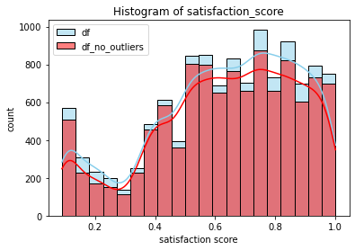

```python
# Create a histogram of satisfaction_score

sns.histplot(data=df, x="satisfaction_score", color="skyblue", label="df", kde=True, bins=20)
sns.histplot(data=df_no_outliers, x="satisfaction_score", color="red", label="df_no_outliers", kde=True, bins=20)
plt.title('Histogram of satisfaction_score')
plt.xlabel('satisfaction score')
plt.ylabel('count')
plt.legend()
plt.show()
```

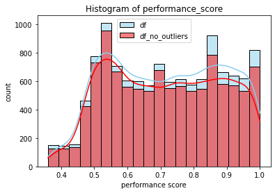

```python
# Create a histogram of performance_score

sns.histplot(data=df, x="performance_score", color="skyblue", label="df", kde=True, bins=20)
sns.histplot(data=df_no_outliers, x="performance_score", color="red", label="df_no_outliers", kde=True, bins=20)
plt.title('Histogram of performance_score')
plt.xlabel('performance score')
plt.ylabel('count')
plt.legend()
plt.show()
```

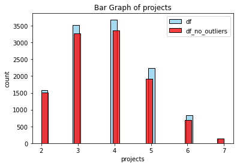

```python
# Create a bar graph of projects

sns.histplot(data=df, x="projects", color="skyblue", label="df")
sns.histplot(data=df_no_outliers, x="projects", color="red", label="df_no_outliers")
plt.title('Bar Graph of projects')
plt.xlabel('projects')
plt.ylabel('count')
plt.legend()
plt.show()
```

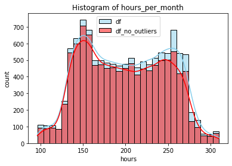

```python
# Create a histogram of hours_per_month

sns.histplot(data=df, x="hours_per_month", color="skyblue", label="df", kde=True, bins=30)
sns.histplot(data=df_no_outliers, x="hours_per_month", color="red", label="df_no_outliers", kde=True, bins=30)
plt.title('Histogram of hours_per_month')
plt.xlabel('hours')
plt.ylabel('count')
plt.legend()
plt.show()
```

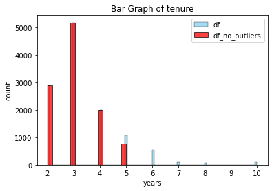

```python
# Create a bar graph of tenure

sns.histplot(data=df, x="tenure", color="skyblue", label="df")
sns.histplot(data=df_no_outliers, x="tenure", color="red", label="df_no_outliers")
plt.title('Bar Graph of tenure')
plt.xlabel('years')
plt.ylabel('count')
plt.legend()
plt.show()
```

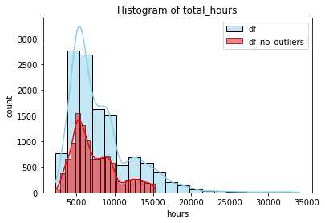

```python
# Create a histogram of performance_score

sns.histplot(data=df, x="total_hours", color="skyblue", label="df", kde=True, bins=20)
sns.histplot(data=df_no_outliers, x="total_hours", color="red", label="df_no_outliers", kde=True, bins=20)
plt.title('Histogram of total_hours')
plt.xlabel('hours')
plt.ylabel('count')
plt.legend()
plt.show()
```

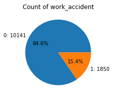

```python
# Create a pie chart of work_accident

fig = plt.figure(figsize=(3,3))
data=df['work_accident'].value_counts()
plt.pie(data,
        labels=[f'{data.index[0]}: {data.values[0]}',
                f'{data.index[1]}: {data.values[1]}'],
        autopct='%1.1f%%'
        )
plt.title('Count of work_accident');
```

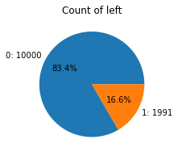

```python
# Create a pie chart of left
fig = plt.figure(figsize=(3,3))
data=df['left'].value_counts()
plt.pie(data,
        labels=[f'{data.index[0]}: {data.values[0]}',
                f'{data.index[1]}: {data.values[1]}'],
        autopct='%1.1f%%'
        )
plt.title('Count of left');
```

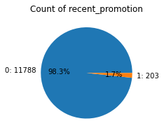

```python
# Create a pie chart of recent_promotion

fig = plt.figure(figsize=(3,3))
data=df['recent_promotion'].value_counts()
plt.pie(data,
        labels=[f'{data.index[0]}: {data.values[0]}',
                f'{data.index[1]}: {data.values[1]}'],
        autopct='%1.1f%%'
        )
plt.title('Count of recent_promotion');
```

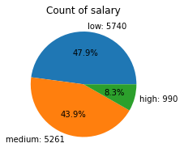

```python
# Create a pie chart of salary

fig = plt.figure(figsize=(3,3))
data=df['salary'].value_counts()
plt.pie(data,
        labels=[f'{data.index[0]}: {data.values[0]}',
                f'{data.index[1]}: {data.values[1]}',
                f'{data.index[2]}: {data.values[2]}'],
        autopct='%1.1f%%'
        )
plt.title('Count of salary');
```

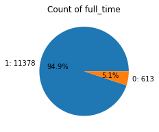

```python
# Create a pie chart of full_time

fig = plt.figure(figsize=(3,3))
data=df['full_time'].value_counts()
plt.pie(data,
        labels=[f'{data.index[0]}: {data.values[0]}',
                f'{data.index[1]}: {data.values[1]}'],
        autopct='%1.1f%%'
        )
plt.title('Count of full_time');
```

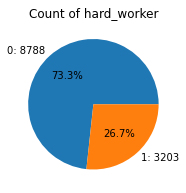

```python
# Create a pie chart of hard_worker

fig = plt.figure(figsize=(3,3))
data=df['hard_worker'].value_counts()
plt.pie(data,
        labels=[f'{data.index[0]}: {data.values[0]}',
                f'{data.index[1]}: {data.values[1]}'],
        autopct='%1.1f%%'
        )
plt.title('Count of hard_worker');
```

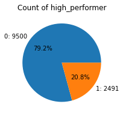

```python
# Create a pie chart of high_performer

fig = plt.figure(figsize=(3,3))
data=df['high_performer'].value_counts()
plt.pie(data,
        labels=[f'{data.index[0]}: {data.values[0]}',
                f'{data.index[1]}: {data.values[1]}'],
        autopct='%1.1f%%'
        )
plt.title('Count of high_performer');
```

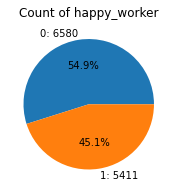

```python
# Create a pie chart of happy_worker

fig = plt.figure(figsize=(3,3))
data=df['happy_worker'].value_counts()
plt.pie(data,
        labels=[f'{data.index[0]}: {data.values[0]}',
                f'{data.index[1]}: {data.values[1]}'],
        autopct='%1.1f%%'
        )
plt.title('Count of happy_worker');
```

```python
df['department'].value_counts()
```

```
sales          3239
technical      2244
support        1821
IT              976
RandD           694
product_mng     686
marketing       673
accounting      621
hr              601
management      436
Name: department, dtype: int64
```

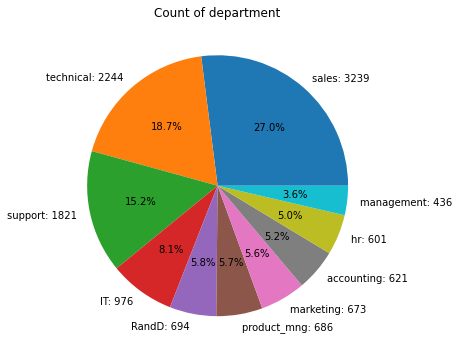

```python
# Create a pie chart of department

fig = plt.figure(figsize=(6,6))
data=df['department'].value_counts()
plt.pie(data,
        labels=[f'{data.index[0]}: {data.values[0]}',
                f'{data.index[1]}: {data.values[1]}',
                f'{data.index[2]}: {data.values[2]}',
                f'{data.index[3]}: {data.values[3]}',
                f'{data.index[4]}: {data.values[4]}',
                f'{data.index[5]}: {data.values[5]}',
                f'{data.index[6]}: {data.values[6]}',
                f'{data.index[7]}: {data.values[7]}',
                f'{data.index[8]}: {data.values[8]}',
                f'{data.index[9]}: {data.values[9]}'],
        autopct='%1.1f%%'
        )
plt.title('Count of department');
```

```python
df.columns
```

```
Index(['satisfaction_score', 'performance_score', 'projects',
       'hours_per_month', 'tenure', 'work_accident', 'left',
       'recent_promotion', 'department', 'salary', 'total_hours', 'full_time',
       'hard_worker', 'high_performer', 'happy_worker'],
      dtype='object')
```

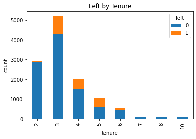

```python
# Visualize the distribution of left among tenure

pd.crosstab(df['tenure'],df['left']).plot.bar(stacked=True)
plt.title('Left by Tenure')
plt.ylabel('count')
plt.show();
```

```python
#Calculate the percent of left by tenure

percent_left_by_tenure = pd.crosstab(df['tenure'], df_no_outliers['left'], normalize='index').mul(100).round(2)

# Rename columns for clarity
percent_left_by_tenure.columns = ['retained', 'left']

percent_left_by_tenure
```

| tenure | retained | left |
| --- | --- | --- |
| 2 | 99.03 | 0.97 |
| 3 | 84.89 | 15.11 |
| 4 | 78.05 | 21.95 |
| 5 | 59.72 | 40.28 |
| 6 | 81.05 | 18.95 |

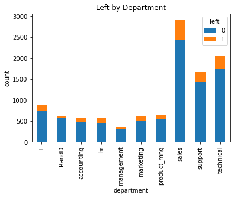

```python
# Visualize the distribution of left among different departments

pd.crosstab(df_no_outliers['department'],df_no_outliers['left']).plot.bar(stacked=True)
plt.title('Left by Department')
plt.ylabel('count')
plt.show();
```

```python
# Most of the departments ratios of retained to left employees are within a close range (14-16%)
# RandD and management have higher retention levels than other departments
# HR has a slightly higher left levels than other departments

percent_df_no_outliers = pd.crosstab(df_no_outliers['department'], df_no_outliers['left'], normalize='index').mul(100).round(2)

# Rename columns for clarity if needed
percent_df_no_outliers.columns = ['retained', 'left']

percent_df_no_outliers
```

| department | retained | left |
| --- | --- | --- |
| IT | 84.84 | 15.16 |
| RandD | 89.89 | 10.11 |
| accounting | 83.69 | 16.31 |
| hr | 81.72 | 18.28 |
| management | 86.76 | 13.24 |
| marketing | 84.77 | 15.23 |
| product_mng | 85.06 | 14.94 |
| sales | 83.78 | 16.22 |
| support | 85.01 | 14.99 |
| technical | 84.29 | 15.71 |

```python
# Does department significantly affect whether an employee stays or leaves?

# Null Hypothesis: The rate of employee retention vs leaving does not signifcantly vary by department type.
# Alternative Hypothesis: The rate of employee retention vs leaving does significantly vary by department type.

# Import library for a chi-square test
from scipy.stats import chi2_contingency

# Perform a chi-square test for df_no_outliers
chi2_statistic, p_value, degrees_of_freedom, expected_frequencies = chi2_contingency(percent_df_no_outliers[['retained', 'left']])

print(f"Chi2 Statistic: {chi2_statistic}")
print(f"P-value: {p_value}")
print(f"Degrees of Freedom: {degrees_of_freedom}")
print("Expected Frequencies Table:")
print(expected_frequencies)
```

```
Chi2 Statistic: 3.2558430620289003
P-value: 0.9532821040215409
Degrees of Freedom: 9
Expected Frequencies Table:
[[84.981 15.019]
 [84.981 15.019]
 [84.981 15.019]
 [84.981 15.019]
 [84.981 15.019]
 [84.981 15.019]
 [84.981 15.019]
 [84.981 15.019]
 [84.981 15.019]
 [84.981 15.019]]
```

```python
# Recreate the process for the general dataframe (with outliers)
percent_df = pd.crosstab(df['department'], df['left'], normalize='index').mul(100).round(2)

# Rename columns for clarity if needed
percent_df.columns = ['retained', 'left']

# Perform a chi-square test for no_outliers data
chi2_statistic, p_value, degrees_of_freedom, expected_frequencies = chi2_contingency(percent_df[['retained', 'left']])

print(f"Chi2 Statistic: {chi2_statistic}")
print(f"P-value: {p_value}")
print(f"Degrees of Freedom: {degrees_of_freedom}")
print("Expected Frequencies Table:")
print(expected_frequencies)
```

```
Chi2 Statistic: 3.361596902042104
P-value: 0.9482198280334139
Degrees of Freedom: 9
Expected Frequencies Table:
[[83.912 16.088]
 [83.912 16.088]
 [83.912 16.088]
 [83.912 16.088]
 [83.912 16.088]
 [83.912 16.088]
 [83.912 16.088]
 [83.912 16.088]
 [83.912 16.088]
 [83.912 16.088]]
```

```python
"""
Interpretation of Chi-Square test:

The test shows that I cannot accept the alternative hypothesis, meaning I fail to reject the null hypothesis,
because the p-value is 0.953 for df_no_outliers and 0.948, which both are much greater than my threshold of significance at 0.05.
The scores of employee retention versus leaving do not significantly vary by department. This indicates that
it is very unlikely that department type has any affect on employee retention. No employee in one department is
statistically more likely to leave than any other department, even though the actual reported rates of retention
do vary.

Impact:

As a result, I have chosen to not move forward with transforming this variable to many numerical variables in
order to complete a logistic regression. To complete this model, it is presumed that all variables will be
correlated with the target variable, "left", Thus, I will drop this variable from df_no_outliers,
as it is not usable for a logistic regression. While the machine learning models do not
this assumption, transforming this variable into a numerical data type would lead to many new variables created
and could harm the model leading to overfitting, so I have also removed it from the original df.

However, this finding is informational for the hr department regardless of the model because they are able to infer
that there is not a significant problem only in one or two departments to focus on. It suggests a solution to raise
employee retention rates may be applied more broadly across the company and not tailored individually to departments.

"""
```

[output not shown]

```python
# Drop the column 'department' from df_no_outliers

df_no_outliers = df_no_outliers.drop(columns=['department'])

# Check columns

print(df_no_outliers.columns)
```

```
Index(['satisfaction_score', 'performance_score', 'projects',
       'hours_per_month', 'tenure', 'work_accident', 'left',
       'recent_promotion', 'salary', 'total_hours', 'full_time', 'hard_worker',
       'high_performer', 'happy_worker'],
      dtype='object')
```

```python
# Drop the column 'department' from df

df = df.drop(columns=['department'])

# Check columns

print(df.columns)
```

```
Index(['satisfaction_score', 'performance_score', 'projects',
       'hours_per_month', 'tenure', 'work_accident', 'left',
       'recent_promotion', 'salary', 'total_hours', 'full_time', 'hard_worker',
       'high_performer', 'happy_worker'],
      dtype='object')
```

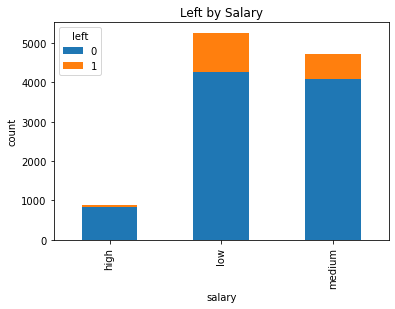

```python
# Visualize the distribution of left among different salaries

pd.crosstab(df_no_outliers['salary'],df_no_outliers['left']).plot.bar(stacked=True)
plt.title('Left by Salary')
plt.ylabel('count')
plt.show();
```

```python
# I have noticed that a far smaller percentage of high salary employees left the company than low salary employees.
# This indicates that there possibly could be a correlation between salary and left.
```

```python
# Transform the `salary` column from string into an ordinal numeric category
# low = 0, medium=1, high=2
df['salary'] = (df['salary'].astype('category').cat.set_categories(['low', 'medium', 'high']).cat.codes)

# Check the first few df rows

df.head()
```

|  | satisfaction_score | performance_score | projects | hours_per_month | tenure | work_accident | left | recent_promotion | salary | total_hours | full_time | hard_worker | high_performer | happy_worker |
| --- | --- | --- | --- | --- | --- | --- | --- | --- | --- | --- | --- | --- | --- | --- |
| 0 | 0.38 | 0.53 | 2 | 157 | 3 | 0 | 1 | 0 | 0 | 5652 | 1 | 0 | 0 | 0 |
| 1 | 0.80 | 0.86 | 5 | 262 | 6 | 0 | 1 | 0 | 1 | 18864 | 1 | 1 | 0 | 1 |
| 2 | 0.11 | 0.88 | 7 | 272 | 4 | 0 | 1 | 0 | 1 | 13056 | 1 | 1 | 0 | 0 |
| 3 | 0.72 | 0.87 | 5 | 223 | 5 | 0 | 1 | 0 | 0 | 13380 | 1 | 0 | 0 | 1 |
| 4 | 0.37 | 0.52 | 2 | 159 | 3 | 0 | 1 | 0 | 0 | 5724 | 1 | 0 | 0 | 0 |

```python
# For df_no_outliers
# Transform the `salary` column from string into an ordinal numeric category
# low = 0, medium=1, high=2
df_no_outliers['salary'] = (df_no_outliers['salary'].astype('category').cat.set_categories(['low', 'medium', 'high']).cat.codes)

# Check the first few df rows

df_no_outliers.head()
```

|  | satisfaction_score | performance_score | projects | hours_per_month | tenure | work_accident | left | recent_promotion | salary | total_hours | full_time | hard_worker | high_performer | happy_worker |
| --- | --- | --- | --- | --- | --- | --- | --- | --- | --- | --- | --- | --- | --- | --- |
| 0 | 0.38 | 0.53 | 2 | 157 | 3 | 0 | 1 | 0 | 0 | 5652 | 1 | 0 | 0 | 0 |
| 1 | 0.11 | 0.88 | 7 | 272 | 4 | 0 | 1 | 0 | 1 | 13056 | 1 | 1 | 0 | 0 |
| 2 | 0.72 | 0.87 | 5 | 223 | 5 | 0 | 1 | 0 | 0 | 13380 | 1 | 0 | 0 | 1 |
| 3 | 0.37 | 0.52 | 2 | 159 | 3 | 0 | 1 | 0 | 0 | 5724 | 1 | 0 | 0 | 0 |
| 4 | 0.41 | 0.50 | 2 | 153 | 3 | 0 | 1 | 0 | 0 | 5508 | 1 | 0 | 0 | 0 |

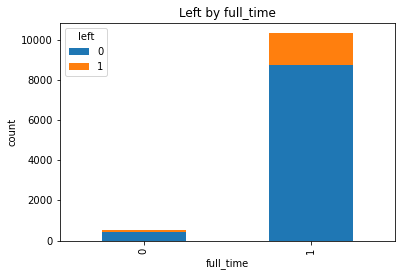

```python
# Visualize the distribution of left among full time vs part time workers

pd.crosstab(df_no_outliers['full_time'],df_no_outliers['left']).plot.bar(stacked=True)
plt.title('Left by full_time')
plt.ylabel('count')
plt.show();
```

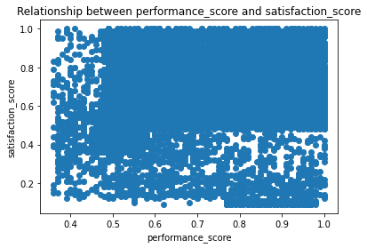

```python
# Create a scatterplot to show the relationship between satisfaction score and performance score

plt.scatter(df_no_outliers['performance_score'], df_no_outliers['satisfaction_score'])
plt.xlabel('performance_score')
plt.ylabel('satisfaction_score')
plt.title('Relationship between performance_score and satisfaction_score')
plt.show();
```

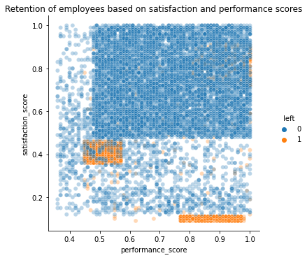

```python
# Show the relationship between recent_promotion, tenure, and left

sns.relplot(data=df_no_outliers, x="performance_score", y="satisfaction_score", hue="left", alpha=0.3)
plt.title('Retention of employees based on satisfaction and performance scores')
plt.show();
```